# Section 1 - Document Clustering

**Student Name: Xinyu Zhang**

**Student ID: 35486244**

## Q1 Expectation Maximisation

### Q1-I

### Write mathematical formulations of the optimization functions of maximum likelihood estimation (MLE) for the document clustering model with complete data and incomplete data, respectively. Then briefly describe why MLE with incomplete data is hard to optimize.

### 1.Maximum likelihood estimation (MLE) with complete data

**Parameter and variable declaration**

- $D=\{d_1, d_2, \dots, d_N\}$: Represents a collection of N documents.
- $K$: Number of clusters.
- $\phi_k$: Represents the prior probability of different documents belonging to cluster k.
- $\mu_{wk}$: Represents the probability that word w belongs to the kth cluster.
- $A$: Represent a vocabulary shared by all documents.

**First, simplify the likelihood function.**

$ P(d | k) = \prod_{w \in d} P(w | k) = \prod_{w \in A} P(w | k)^{c(w,d)} $

**Then add the likelihood to the joint distribution p(k, d) and simplify again.**

$ p(k, d) = p(k)p(d | k) = \varphi_k \prod_{w \in d} \mu_{kw} = \varphi_k \prod_{w \in A} \mu_{kw}^{c(w,d)} $

Next, we'll use $\{d_1, d_2, \dots, d_N\}$ to represent the different documents.

Then, we'll use $\mathbf{Z}_n$ to represent the cluster to which the $n^{th}$ document belongs. $$ \mathbf{z}_n = (z_{n1}, z_{n2}, \dots, z_{nk}) $$ $$ z_{nk} = \begin{cases} 1, & d_n \in C_k \\ 0, & d_n \notin C_k \end{cases} $$ In hard clustering, only one $z_{nk}$ will be equal to 1, while the others will be 0. In soft clustering, $z_{nk}$ represents the probability that document n belongs to different clusters.

**In the end, I need to add $z_{nk}$.**

$ p(d_1, \mathbf{z}_1, \dots, d_N, \mathbf{z}_N) = \prod_{n=1}^{N} \prod_{k=1}^{K} \left( \varphi_k \prod_{w \in A} \mu_{kw}^{c(w,d_n)} \right)^{z_{nk}} $

**Then, using the properties of logarithms, we can convert multiplication into summation.**

**The final optimization function for the complete data is as follows:**

$ \log p(d_1, \mathbf{z}_1, \dots, d_N, \mathbf{z}_N) = \sum_{n=1}^{N} \sum_{k=1}^{K} z_{nk} \left( \log \varphi_k + \sum_{w \in A} c(w,d_n) \log \mu_{kw} \right) $

### 2.Maximum likelihood estimation (MLE) with incomplete data

Since this is incomplete data, we only observe the document data and don't know their categories, so Z is a latent variable.

**To maximize the likelihood function, we need to marginalize the latent variable Z. That is, we consider all possible categories and sum their probabilities.**

**The final optimization function for the incomplete data is as follows:**

$ \log p(D | \theta) = \sum_{n=1}^{N} \log \left( \sum_{k=1}^{K} \varphi_k \prod_{w \in A} \mu_{kw}^{c(w,d_n)} \right) $

### 3.Then briefly describe why MLE with incomplete data is hard to optimize.

With complete data, the optimization function is a logarithm inside the summation symbol, and the parameters are directly contained within the logarithm function. Taking the partial derivative of this function yields a very concise form, allowing for direct solution using the Lagrange multiplier method.

However, with incomplete data, the optimization function is structured such that the logarithm is outside the summation symbol. More precisely, the logarithm function contains the summation term. This makes it difficult to take partial derivatives of the function.

Also, since the categorical variable Z is a hidden variable, the optimization computation becomes more complex.

### Briefly explain the high-level idea of the EM algorithm to find MLE parameter estimates.

**Process of EM Algorithm**

- **Initialization:** The parameters must be randomly initialized as initial guesses.
- **E-step:** Based on the observed data and the current parameter estimates, the posterior probability of the latent variable is calculated.
- **M-step:** The parameters are updated using the posterior probabilities of the latent variables obtained in step E to maximize the calculated expected log-likelihood.
- **Check for Convergence:** After each M-step, the algorithm checks whether the change in the parameter estimates is below a preset threshold or exceeds the maximum number of iterations. If so, the algorithm terminates; otherwise, it returns to step E and continues iterations.

### Q1-II

### Derive Expectation and Maximization steps of the (soft)-EM algorithm for Document Clustering.

**First, the objective function is an auxiliary function, the Q function, as follows:**

$ Q(\theta, \theta^{(t)}) = E_{Z|D, \theta^{(t)}} \left[ \log p(D, Z|\theta) \right] $

where $\theta^{(t)}$ is the parameter for the $t$th iteration.

**the Expectation step:**

The core task of the E-step is to calculate the posterior probability (expected) of the latent variable $z_{nk}$, as $\gamma(z_{nk})$. This value represents the probability that document $d_n$ belongs to category $k$ under the current model parameters $\theta^{(t)}$.

$ \gamma(z_{nk}) = p(z_{nk}=1 | d_n, \theta^{(t)}) $

**According to Bayes' theorem, we can obtain:**

$ \begin{aligned} \gamma(z_{nk}) &= \frac{p(z_{nk}=1|\theta^{(t)}) p(d_n|z_{nk}=1, \theta^{(t)})}{p(d_n|\theta^{(t)})} \\ &= \frac{p(z_{nk}=1|\theta^{(t)}) p(d_n|z_{nk}=1, \theta^{(t)})}{\sum_{j=1}^{K} p(z_{nj}=1|\theta^{(t)}) p(d_n|z_{nj}=1, \theta^{(t)})} \end{aligned} $

**Substituting the specific model parameters into:**

- $p(z_{nk}=1 | \theta^{(t)}) = \varphi_k^{(t)}$
- $p(d_n | z_{nk}=1, \theta^{(t)}) = \prod_{w \in A} (\mu_{kw}^{(t)})^{c(w,d_n)}$

**Finally, we obtain the updated expression for Zn in step E:**

$ \gamma(z_{nk}) = \frac{\varphi_k^{(t)} \prod_{w \in V} (\mu_{kw}^{(t)})^{c(w,d_n)}}{\sum_{j=1}^{K} \varphi_j^{(t)} \prod_{w \in V} (\mu_{jw}^{(t)})^{c(w,d_n)}} $

**Then comes the Maximization step:**

**The goal of the M-step is to find a new set of parameters $\theta^{(t+1)}$ that maximizes the Q function.**

$ \theta^{(t+1)} = \arg\max_{\theta} Q(\theta, \theta^{(t)}) $

Then, we replace $z_{nk}$ in the Q-function with the expectation $E[z_{nk}] = \gamma(z_{nk})$ calculated in the E-step:

$ Q(\theta, \theta^{(t)}) = \sum_{n=1}^{N} \sum_{k=1}^{K} \gamma(z_{nk}) \left( \log \varphi_k + \sum_{w \in V} c(w, d_n) \log \mu_{kw} \right) $

**Finally, we solve the Q-function using the Lagrange multiplier method with constraints ($\sum \varphi_k = 1$ and $\sum \mu_{kw} = 1$), obtaining the parameter update formula:**

$ \varphi_k = \frac{N_k}{N} \quad \text{where} \quad N_k = \sum_{n=1}^{N} \gamma(z_{nk}) $

$ \mu_{kw} = \frac{\sum_{n=1}^{N} \gamma(z_{nk}) c(w, d_n)}{\sum_{w' \in A} \sum_{n=1}^{N} \gamma(z_{nk}) c(w', d_n)} $

### Q1-III Load Task2A.txt file

```python
# Importing required libraries

import pandas as pd
import numpy as np
import matplotlib.pyplot as plt
from sklearn.feature_extraction.text import CountVectorizer, TfidfVectorizer
from sklearn.cluster import KMeans
from sklearn.decomposition import PCA
import pandas as pd
from sklearn.feature_extraction.text import CountVectorizer
from sklearn.feature_extraction.text import TfidfTransformer
import numpy as np
import pandas as pd
import random
import os
```

```python
## read the file (each line of the text file is one document)
with open('Dataset_S2_2025/Task2A.txt', 'r') as file:
    text = file.readlines()
```

```python
# Displaying data with different labels
docs = pd.DataFrame(text)
docs.columns = ["row"]
docs["label"] = df["row"].apply(lambda x: x.split("\t")[0])
docs["text"] = df["row"].apply(lambda x: x.split("\t")[1])
docs.groupby("label").count()
```

| label | row | text |
| --- | --- | --- |
| sci.crypt | 595 | 595 |
| sci.electronics | 591 | 591 |
| sci.med | 594 | 594 |
| sci.space | 593 | 593 |

```python
docs
```

|  | row | label | text |
| --- | --- | --- | --- |
| 0 | sci.crypt\tripem frequently asked questions ar... | sci.crypt | ripem frequently asked questions archive name ... |
| 1 | sci.crypt\tripem frequently asked questions ar... | sci.crypt | ripem frequently asked questions archive name ... |
| 2 | sci.crypt\tripem frequently noted vulnerabilit... | sci.crypt | ripem frequently noted vulnerabilities archive... |
| 3 | sci.crypt\tcertifying authority question answe... | sci.crypt | certifying authority question answered if you ... |
| 4 | sci.crypt\trubber hose cryptanalysis some sick... | sci.crypt | rubber hose cryptanalysis some sick part of me... |
| ... | ... | ... | ... |
| 2368 | sci.space\tre command loss timer re galileo up... | sci.space | re command loss timer re galileo update alan c... |
| 2369 | sci.space\tre gamma ray bursters where are the... | sci.space | re gamma ray bursters where are they i assume ... |
| 2370 | sci.space\tre life on mars in article apr aio ... | sci.space | re life on mars in article apr aio jsc nasa go... |
| 2371 | sci.space\tre what counntries do space surveil... | sci.space | re what counntries do space surveillance the e... |
| 2372 | sci.space\twhy not give billion to first year ... | sci.space | why not give billion to first year lo original... |

2373 rows × 3 columns

### Q1-IV Implement the EM algorithm

```python
# Using get_log_sum_exp function to normalize the data for numerical stability
def get_log_sum_exp(log_probs_matrix):

    max_val_per_row  = np.max(log_probs_matrix, axis=1, keepdims=True) # Max value in each row
    return max_val_per_row  + np.log(np.sum(np.exp(log_probs_matrix - max_val_per_row ), axis=1, keepdims=True))
```

```python
# define the Expectation_step function
def Expectation_step(z_gamma, model, features, soft=True):

    num_documents  = features.shape[1]  # document size
    num_clusters  = model["mu_coeffs"].shape[0] # cluster size
    # Obtaining initialization parameters
    log_phi_coeffs = np.log(model["phi_coeffs"])
    log_mu_coeffs = np.log(model["mu_coeffs"])

    # Calculating the posterior probability of latent variables
    z_gamma = np.dot(log_mu_coeffs, features).T + log_phi_coeffs.T
    # Using get_log_sum_exp function to normalize the data
    logZ = get_log_sum_exp(z_gamma)
    z_gamma -= logZ.reshape(num_documents,1)
    # Converting the logarithm of a parameter to  probability
    z_gamma = np.exp(z_gamma)
    # check the soft clustering or not
    if not soft:
        z_star = np.argmax(z_gamma, axis=1)
        return z_star
    else:
        return z_gamma

# define the Maximization_step function
def Maximization_step(gamma_z_star, model, features, soft=True):

    num_documents  = features.shape[1] # document size
    vocabulary_size  = features.shape[0] # vocabulary size
    num_clusters  = model["mu_coeffs"].shape[0] # cluster size
    # Preventing division by zero
    smoothing_term  = 1e-10 * np.ones((vocabulary_size, num_documents))

    # Updating parameters for soft clustering
    if soft:
        gamma = gamma_z_star
        # Calculating new probabilities for different clusters
        model["phi_coeffs"] = np.sum(gamma, axis=0) / num_documents

        # Calculate new means for all clusters at once
        denominator = np.sum((np.dot(features, gamma)) + 1e-10, axis=0)
        model["mu_coeffs"] = (np.dot(features, gamma) + 1e-10) / denominator
        model["mu_coeffs"] = model["mu_coeffs"].T
    # Updating parameters for hard clustering
    else:
        z_star = gamma_z_star

        for k in range(K):
            model['phi_coeffs'][k] = np.sum(z_star == k) / num_documents
            model['mu_coeffs'][k,:] = np.sum(features[:,z_star==k] + smoothing_term [:,z_star==k], axis=1) / (np.sum(np.sum(features[:,z_star==k] + smoothing_term [:,z_star==k])))

    return model
```

```python
# Initializing two parameters
def two_parameters_init(vocabulary_A_size, num_clusters=4, random_seed=921):
    # init the mu and phi
    np.random.seed(random_seed)
    phi_coeffs = np.ones((num_clusters, 1)) / num_clusters
    mu_coeffs = np.random.rand(num_clusters, vocabulary_A_size)

    mu_coeffs = mu_coeffs / np.sum(mu_coeffs, axis=1)[:, None]
    return {"phi_coeffs": phi_coeffs, "mu_coeffs": mu_coeffs}


# Running the EM algorithm function
def run_em_algorithm(data_features, K=4, max_epoch=10, seed=921, soft=True):

    # Model Parameter Setting
    num_documents  = data_features.shape[1] # number of documents
    vocabulary_size  = data_features.shape[0] # number of unique words (in all documents)
    # Initialization
    current_model = two_parameters_init(vocabulary_size , num_clusters=K, random_seed=seed)
    z_gamma = np.zeros((num_documents, K))

    # Running E Step and M Step
    for epoch in range(1, max_epoch+1):

        # E Step
        updated_z_gamma = Expectation_step(z_gamma, current_model, data_features, soft=soft)

        # M Step
        model = Maximization_step(updated_z_gamma, current_model, data_features, soft=soft)

    # Return Model
    if soft:
        return {"model": current_model, "z_gamma": updated_z_gamma}
    else:
        return {"model": current_model, "updated_z": updated_z_gamma}
```

### Q1-V

### Set the number of clusters K=4, and run the hard clustering (using hard-EM) and soft clustering (using soft-EM) on the provided data.

```python
# save the dataset
df[["label", "text"]].to_csv("Dataset_S2_2025/Task2A.csv",index = False)

# Using tfidf to vectorize text data
def load_and_vectorize_text_data(csv_path, ratio=0.80):
    # get the dataset
    data_frame = pd.read_csv(csv_path)
    data_frame["doc_id"] = data_frame.index
    processed_docs_df  = data_frame
    document_labels  = data_frame['label']

    # Create a matrix which its rows are the documents and columns are the words.
    tfidf_vectorizer_object  = TfidfVectorizer(lowercase=True,stop_words='english',min_df=6,norm='l2')
    # Converting to numerical features
    tfidf_features  = tfidf_vectorizer_object .fit_transform(raw_documents=docs.text.values)

    return {"docs": processed_docs_df, "features": tfidf_features , "labels": document_labels}
```

```python
# get the features
loaded_data_dict  = load_and_vectorize_text_data(csv_path='Dataset_S2_2025/Task2A.csv')
feature_matrix  = loaded_data_dict ['features']
feature_matrix  = feature_matrix .T.toarray()

feature_matrix .shape
```

```
(6986, 2373)
```

```python
# Run soft-EM algorithm on the provided data
soft_clustering_output  = run_em_algorithm(feature_matrix , K=4, max_epoch=15, seed=921, soft=True)
soft_clustering_output
```

```
{'model': {'phi_coeffs': array([0.17150232, 0.16656571, 0.2759001 , 0.38603187]),
  'mu_coeffs': array([[1.21334389e-04, 1.05864137e-06, 2.53296696e-07, ...,
          2.42526377e-06, 9.11157397e-07, 3.34318254e-14],
         [1.84952864e-04, 5.43747115e-13, 1.18923235e-04, ...,
          1.82348307e-12, 1.99420580e-12, 3.22011867e-14],
         [2.16214683e-04, 2.72384204e-04, 3.38778265e-04, ...,
          2.45731511e-04, 1.67803845e-04, 1.83989459e-13],
         [1.08704005e-04, 8.03098351e-06, 1.49329210e-04, ...,
          1.07497496e-03, 5.02289192e-04, 4.07578663e-04]])},
 'z_gamma': array([[1.17489006e-12, 1.00000000e+00, 1.74026715e-17, 3.15149236e-17],
        [1.46363710e-12, 1.00000000e+00, 2.02075929e-19, 1.81584401e-18],
        [2.30496446e-15, 1.00000000e+00, 2.78084656e-23, 2.58433549e-17],
        ...,
        [7.52493446e-14, 9.79359006e-15, 6.03515322e-11, 1.00000000e+00],
        [6.73536431e-09, 4.53268603e-13, 8.41774496e-01, 1.58225497e-01],
        [3.56093106e-22, 5.68012656e-15, 4.51079868e-05, 9.99954892e-01]])}
```

```python
# Run hard-EM algorithm on the provided data
hard_clustering_output  = run_em_algorithm(feature_matrix , K=4, max_epoch=15, seed=921, soft=False)
hard_clustering_output
```

```
{'model': {'phi_coeffs': array([[0.18036241],
         [0.22587442],
         [0.22123894],
         [0.37252423]]),
  'mu_coeffs': array([[3.75289845e-04, 7.01065610e-05, 1.47194070e-11, ...,
          1.26483277e-04, 7.67515976e-05, 2.63694866e-04],
         [1.48759574e-04, 9.79861625e-05, 3.41875578e-04, ...,
          3.64581005e-04, 2.06351135e-04, 1.42528840e-11],
         [9.88188243e-05, 1.08013167e-04, 1.76934081e-04, ...,
          4.10121139e-04, 2.62291644e-04, 3.50670624e-04],
         [8.00498381e-05, 3.07401424e-05, 1.23465648e-04, ...,
          7.46914985e-04, 3.13753587e-04, 9.85098998e-05]])},
 'updated_z': array([3, 3, 3, ..., 3, 2, 1])}
```

### Q1-VI

### Perform a PCA on the clusterings that you get based on the Mixture Models. Then, plot the obtained clusters with different colors where x and y axes are the first two principal components. Based on your plots, discuss how and why the hard and soft clustering are different in a markdown cell.

```python
import numpy as np

# Find the cluster with the maximum probability (since we have soft assignment here)
soft_cluster_predictions  = np.argmax(soft_clustering_output['z_gamma'], axis=1)
```

```python
soft_cluster_predictions .shape
```

```
(2373,)
```

```python
# perform pca (principal components analysis),Reducing features to two dimensions
pca = PCA(n_components=2)
_2D_features = pca.fit_transform(features.T)
```

```python
features.T.shape
```

[output not shown]

[output not shown]

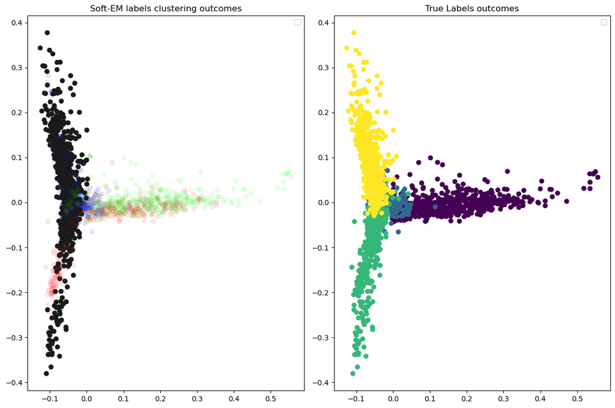

```python
# Enhancing the contrast between numerical probabilities
soft_assignment_color_scores  = soft_clustering_output["z_gamma"]
soft_assignment_color_scores  = np.where(soft_assignment_color_scores  < 0.1, 0.1, soft_assignment_color_scores )
soft_assignment_color_scores  = np.where(soft_assignment_color_scores  > 0.9, 1, soft_assignment_color_scores )

# plot the Soft-EM outcome
_, axs = plt.subplots(1, 2, figsize=(12, 8), tight_layout=True)
axs[0].scatter(x=_2D_features[:,0],y=_2D_features[:,1],c=soft_assignment_color_scores)
axs[0].set_title('Soft-EM labels clustering outcomes')
axs[0].legend()

# plot the original data
axs[1].scatter(x=_2D_features[:,0],y=_2D_features[:,1], c=docs.label.cat.codes)
axs[1].set_title('True Labels outcomes')
axs[1].legend()

plt.show()
```

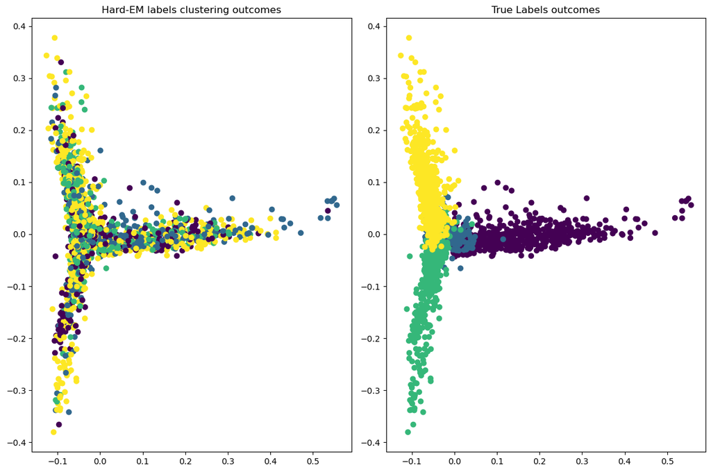

```python
# plot the Hard-EM outcome
_, axs = plt.subplots(1, 2, figsize=(12, 8), tight_layout=True)
axs[0].scatter(x=_2D_features[:,0],y=_2D_features[:,1], c=hard_clustering_output["updated_z"])
axs[0].set_title('Hard-EM labels clustering outcomes')

# plot the original data
axs[1].scatter(x=_2D_features[:,0],y=_2D_features[:,1], c=docs.label.cat.codes)
axs[1].set_title('True Labels outcomes')
plt.show()
```

### Based on your plots, discuss how and why the hard and soft clustering are different

As can be seen in the first figure, **the soft clustering results** produce a more realistic and **reasonable representation of the ambiguous and overlapping areas** in the data than hard clustering. This is because soft clustering considers the influence of all data points when updating cluster centers, but each data point's contribution is weighted according to its probability of belonging to that cluster. A point on the boundary between two clusters will simultaneously pull the centers of both clusters closer to it, resulting in a fuzzy cluster boundary.

As can be seen in the second figure, **the hard clustering results** produce **a large number of misclassifications** in areas where clusters are close or overlapping. This is because hard clustering calculates the probability of a data point belonging to each cluster and then forcibly assigns the data point to the cluster with the highest probability.